# In-Class: Lines & Polygons

*Look to see which ones are in the box*

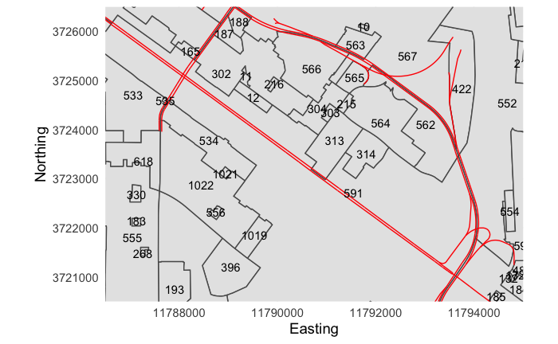

```r
ggplot() +
  geom_sf( data = rva_districts ) +
  geom_sf( data = downtown,
           color = "red") +
  geom_sf_text( aes(label=OBJECTID),
                data = rva_districts) +
  coord_sf( xlim = c(11786500, 11795000),
            ylim = c(3720500, 3726500),
            expand=FALSE,
            datum = st_crs(rva_roads) ) +
  xlab("Easting") +
  ylab("Northing")
```

*Now grab them and put them into a table.*

```r
rva_districts %>%
  filter( OBJECTID %in% c( 188, 187, 302,
                           11, 12, 216,
                           566, 565, 304,
                           303, 215, 564,
                           562, 314, 591) ) %>%
  mutate( Area = units::set_units(st_area(geometry), m^2 ) ) %>%
  arrange( `Zoning Code` ) %>%
  st_drop_geometry() %>%
  select( `Zoning Code`,
          `Object ID` = OBJECTID,
          Area ) %>%
  kable( caption = "Table 1: Zoning Districts in downtown Richmond Virginia enclsed by Broad Street, Bevidere, and I-95." ) %>%
  kableExtra::kable_material()
```

Table 1: Zoning Districts in downtown Richmond Virginia enclsed by Broad Street, Bevidere, and I-95.

| Zoning Code | Object ID | Area |
| --- | --- | --- |
| B-1 | 11 | 3760.554 [m^2] |
| B-2 | 188 | 15821.844 [m^2] |
| B-2 | 304 | 43812.688 [m^2] |
| B-4 | 591 | 1757905.426 [m^2] |
| B-6 | 216 | 2629.718 [m^2] |
| B-7 | 565 | 23396.267 [m^2] |
| CM | 314 | 46346.092 [m^2] |
| R-6 | 302 | 176368.666 [m^2] |
| R-63 | 566 | 120600.922 [m^2] |
| R-73 | 187 | 19356.374 [m^2] |
| RO-2 | 12 | 15412.604 [m^2] |
| RO-2 | 303 | 5540.451 [m^2] |
| RO-3 | 215 | 5682.554 [m^2] |
| RO-3 | 562 | 121985.914 [m^2] |
| RP | 564 | 124549.993 [m^2] |

4. Download the Richmond School shapefile above and make a table of all the schools that are within 1000 ft of any highways in Richmond, Virginia.

*So let’s take a look a the raw data. I’m going to plot the highways and highway interchanges with a 1000ft buffer (remember, the default datum for these data are ftUS). Then overlay the schools on top of it.*

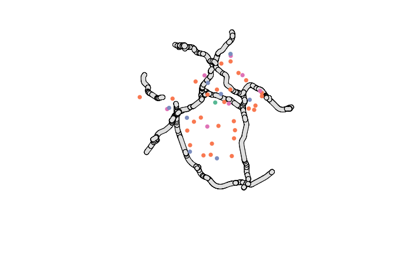

```r
rva_roads %>%
  filter( Type %in% c("Highway",
                      "Highway Interchange") ) %>%
  st_geometry() %>%
  st_simplify() -> highways

plot( st_buffer( st_geometry(highways), dist=1000), col="grey90" )
rva_schools %>%
  select( Type, geometry ) %>%
  plot( add=TRUE, pch=16 )
```

*Looks like there are some schools here. So let’s do a spatial join using st_intersection and then plot it out as a table.*

```r
highways %>%
  st_buffer( dist = 1000 ) -> highway_buffer  # make buffers


# Filter schools
rva_schools %>%
  st_intersection( highway_buffer ) %>%
  arrange( Type, `School Name`) %>%
  select( `School Name`, Type, Address ) %>%
  st_drop_geometry() %>%
  knitr::kable(caption = "Table 2: Public schools that are within 1000 feet of a highway.") %>%
  kableExtra::kable_material()
```

```
attribute variables are assumed to be spatially constant throughout all geometries
```

Table 2: Public schools that are within 1000 feet of a highway.

|  | School Name | Type | Address |
| --- | --- | --- | --- |
| 22 | Fairfield Court Elementary School | Elementary | 2510 Phaup St |
| 22.1 | Fairfield Court Elementary School | Elementary | 2510 Phaup St |
| 22.2 | Fairfield Court Elementary School | Elementary | 2510 Phaup St |
| 22.3 | Fairfield Court Elementary School | Elementary | 2510 Phaup St |
| 40 | George Washington Carver Elementary School | Elementary | 1110 W Leigh St |
| 40.1 | George Washington Carver Elementary School | Elementary | 1110 W Leigh St |
| 40.2 | George Washington Carver Elementary School | Elementary | 1110 W Leigh St |
| 40.3 | George Washington Carver Elementary School | Elementary | 1110 W Leigh St |
| 43 | John B Cary Elementary School | Elementary | 3021 Maplewood Ave |
| 43.1 | John B Cary Elementary School | Elementary | 3021 Maplewood Ave |
| 43.2 | John B Cary Elementary School | Elementary | 3021 Maplewood Ave |
| 43.3 | John B Cary Elementary School | Elementary | 3021 Maplewood Ave |
| 43.4 | John B Cary Elementary School | Elementary | 3021 Maplewood Ave |
| 43.5 | John B Cary Elementary School | Elementary | 3021 Maplewood Ave |
| 43.6 | John B Cary Elementary School | Elementary | 3021 Maplewood Ave |
| 43.7 | John B Cary Elementary School | Elementary | 3021 Maplewood Ave |
| 43.8 | John B Cary Elementary School | Elementary | 3021 Maplewood Ave |
| 43.9 | John B Cary Elementary School | Elementary | 3021 Maplewood Ave |
| 25 | Albert H Hill Middle School | Middle | 3400 Patterson Ave |
| 23 | Armstrong High School | High | 2300 Cool Lane |
| 23.1 | Armstrong High School | High | 2300 Cool Lane |

### Cleaning up files.

We can clean up all the raw data hanging around by executing the following code.

```r
unlink("Zoning_Districts.*")
unlink("f4996b83-ce9c-4eef-94d0-dc53e4e269e32020314-1-5d1dz8.ribms.*")
unlink("Centerlines-sh*", recursive = TRUE, force=TRUE, expand = TRUE )
```